# Pneumonia SAR Models

### 4.2.1 SAR assumptions

As we corrected for spatial autocorrelation, we must ensure our models do not violate the autocorrelation assumption. We define a function to plot the residuals of our models and corroborate randomness.

```r
# Residual plot function for SarLm objects
residual.plot <- function(model, year) {
  plot(residuals(model) ~ model$fitted.values, xlab = "fitted values", ylab = "residuals", main = year)
  abline(h=0, lty="dotted")
  lines(lowess(model$fitted.values, residuals(model)), col="red")
}
```

We also check other assumptions as in our linear models.

```
##
## ***** 2004 *****
```

```
## Normal
## Homocedastic
## Non-spatially autocorrelated
##
## ***** 2007 *****
```

```
## Normal
## Homocedastic
## Non-spatially autocorrelated
##
## ***** 2011 *****
```

```
## Normal
## Homocedastic
## Non-spatially autocorrelated
##
## ***** 2014 *****
```

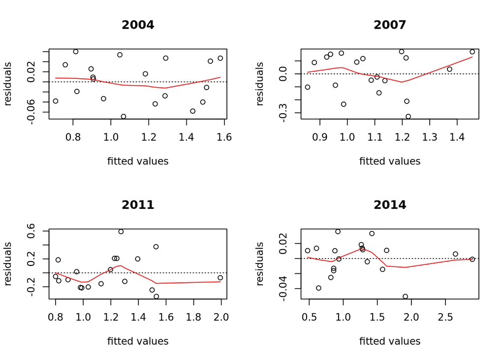

```
## Normal
## Homocedastic
## Non-spatially autocorrelated
```

```r
# Model check
par(resetPar())
par(mfrow=c(2,2))
invisible(lapply(1:length(pneuNames), function (x){
  saryear <- sarReg[[x]];
  cat(paste0('\n***** 20', years[[x]], ' *****\n'))
  # Linearity:
  residual.plot(saryear, paste0('20', years[[x]]))
  # Residuals normality: Shapiro Wilk test
  normality <- shapiro.test(residuals(saryear))
  if (normality$p.value >= 0.05) {cat('Normal\n')} else {cat('non-normal\n')}
  # Heteroscedasticity: Breusch Pagan test
  if (class(saryear)[1] %in% c('SlX','lm')) {homos <- bptest(saryear)} else { homos <- bptest.Sarlm(saryear)}
  if (homos$p.value >= 0.05) {cat('Homocedastic\n')} else {cat('Heteroscedastic\n')}
  # autocorrelation
  moran <- moran.test(residuals(saryear), nb2listw(get(spatialW[[x]])[[x]]))
  if (moran$p.value >= 0.05) {cat('Non-spatially autocorrelated\n')} else {cat('Spatially autocorrelated\n')}
}))
```

# 5 Inference

## 5.1 Impacts

If you are familiar with SAR models, you know they are difficult to interpret because the coefficients are a combination of direct and indirect effects. Direct effects are the effects of the spatial unit on itself. Indirect effects are the effects spatial units have on other spatial units, also known as spillover effects.

We assess the contribution of our variables trought impacts. We compute the impacts of the models’ spatial lagged covariates using a simulation scheme in which the distributions for the impact measures are calculated. We also compute z-values and $p-values$ for the impacts based on the simulations.

```r
# Impacts
impactModels <- lapply(c(1,3:4), function (x) {summary(impacts(sarReg[[x]], listw = nb2listw(get(spatialW[[x]])[[x]]), R = 1000), zstats = T, short=TRUE, density = T)}) # 2007: ols model doesn't have impacts
names(impactModels) <- pneuNames[c(1,3:4)]
impactModels
```

```
## $pneu04
## Impact measures (SDEM, estimable, n):
##              Direct    Indirect       Total
## IDD     -0.01076405 -0.10080797 -0.11157202
## DEP     -0.03443214 -0.07768419 -0.11211633
## CVV      0.51225899  0.96676561  1.47902460
## ESC     -0.05644063          NA -0.05644063
## NBI      0.04810060  0.05958261  0.10768321
## lag3SMR -2.14253938          NA -2.14253938
## ========================================================
## Standard errors:
##              Direct   Indirect       Total
## IDD     0.013499193 0.02233614 0.019550579
## DEP     0.005013745 0.01728071 0.018726444
## CVV     0.091710395 0.43853328 0.406967381
## ESC     0.007676552         NA 0.007676552
## NBI     0.009399267 0.02450460 0.022499351
## lag3SMR 0.147753614         NA 0.147753614
## ========================================================
## Z-values:
##             Direct  Indirect      Total
## IDD      -0.797385 -4.513222  -5.706840
## DEP      -6.867549 -4.495428  -5.987059
## CVV       5.585615  2.204543   3.634258
## ESC      -7.352342        NA  -7.352342
## NBI       5.117484  2.431487   4.786059
## lag3SMR -14.500758        NA -14.500758
##
## p-values:
##         Direct     Indirect  Total
## IDD     0.42523    6.385e-06 1.1509e-08
## DEP     6.5314e-12 6.943e-06 2.1367e-09
## CVV     2.3287e-08 0.027486  0.00027878
## ESC     1.9473e-13 NA        1.9473e-13
## NBI     3.0964e-07 0.015037  1.7009e-06
## lag3SMR < 2.22e-16 NA        < 2.22e-16
##
##
## $pneu11
## Impact measures (lag, exact):
```

[output cut: 50 more lines]

```
## NUT  -11.0822301  -0.2866835  -3.028454
## CVV   -0.3555984  -4.5576516  -6.003042
## IPSE  17.2968885  -2.1927822   2.356812
## VAC    6.5032786   6.3605791  10.523790
## NBI   -1.9154488 -14.0030770 -12.351791
##
## p-values:
##      Direct     Indirect   Total
## TEM  2.1760e-14 < 2.22e-16 < 2.22e-16
## CPM  0.294539   < 2.22e-16 < 2.22e-16
## NUT  < 2.22e-16 0.774355   0.0024581
## CVV  0.722141   5.1729e-06 1.9365e-09
## IPSE < 2.22e-16 0.028323   0.0184326
## VAC  7.8588e-11 2.0099e-10 < 2.22e-16
## NBI  0.055435   < 2.22e-16 < 2.22e-16
```